## Week 01 Wednesday

August 28, 2024

# Goals

1. What frameworks can we use for A01?
2. Ethics/Impacts/Stakeholders case study

## What frameworks can we use for A01?

A01 asks us to consider the social, environmental, and ethical implications of technological solutions.

- What do we mean by *Social Implications?*
- What do we mean by *Environmental Implications?*
- What do we mean by *Ethical Implications?*

### What do we mean by "Social Implications?"

Aside from questions of *should* there are questions of *does*. How *does* a robot's design influence the social structures in which it operates? Let's think about these for the following

- A factory robot that welds or assembles
- A self-driving car
- Educational social robot designed to improve conflict-resolution skills in young children
- Educational mobile robot (like Romi)

### What do we mean by "Environmental Implications?"

When we talk about environmental impact of these robots, we might be talking about the world as a whole (e.g. climate change, waste accumulation, sustainability), but we are *probably* at least talking about the *natural* environment adjacent to the robot and how that might be affected by it at some point during its life cycle. What can we say about the environmental impacts of:

- An ocean cleanup robot
- A logging robot
- A chatbot like ChatGPT

Think about both *primary* and *secondary* effects each of these robots could have on its environment.

### What do we mean by "Ethical Considerations?"

When we talk about "ethical considerations" in the context of engineering and robotics specifically, a lot of the time we are talking about what people (in many cases, engineers) **should do.** For example, established roboticist Rodney Brooks developed his own Three Laws of Robotics that seem to govern how engineers should design and test robots before moving them towards a commercial product. But Robot Ethics can deal with many things:

- How robots should behave towards (people, property, animals, plants)
- How engineers designing robots should behave
- How people should behave in the company of and/or towards robots

**Let's focus in temporarily *just* on how robot *engineers* and possibly their creations should behave**.

## The IEEE code of ethics.... is it enough?

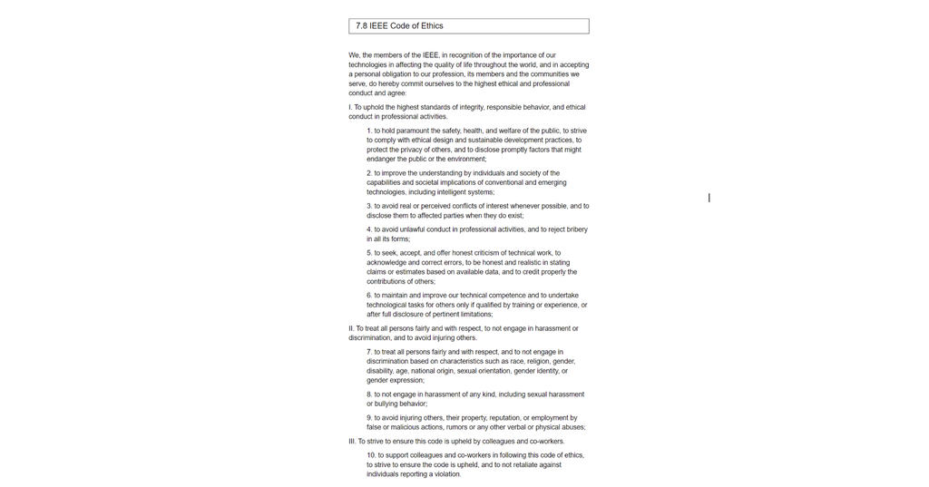

[interactive chart not shown]

## Summary of ORI framework (just one that you could use):

- Identify your robot's use case (intended or unintended or both)
- Identify stakeholders, select key stakeholders to engage with
- Listen to the stakeholders
- Map "personas" of your stakeholders & identify their values
  - Create a persona chart
  - Consider robotics laws/principles
  - Consider community values
- Discover tensions in values
- Discover tensions in activities
- Discover tensions in technologies
- Synthesize
  - Organize tensions and values thematically

## Break into groups! Time for an exercise

Cruise [IEEE robotics news](https://spectrum.ieee.org/tag/robotics) for a key story.

In groups of 3, answer the following questions. **Do some searching** to answer these questions. Don't just rely on the one story!!

- What environmental impacts might this project have?
- What social impacts might this project have?
- What economic impacts might this project have?
- What ethical concerns are there with the project?
- What *stakeholders* can you identify in the article?
  - What stakeholders may there be that are *not* mentioned?
  - What *value tensions* can you see between stakeholders?